# Lab 6 - Decision Trees

## Question 4

Next, let’s find out whether pruning the tree might lead to improved results.

Use `cv.tree()` to determine the optimal level of tree complexity.

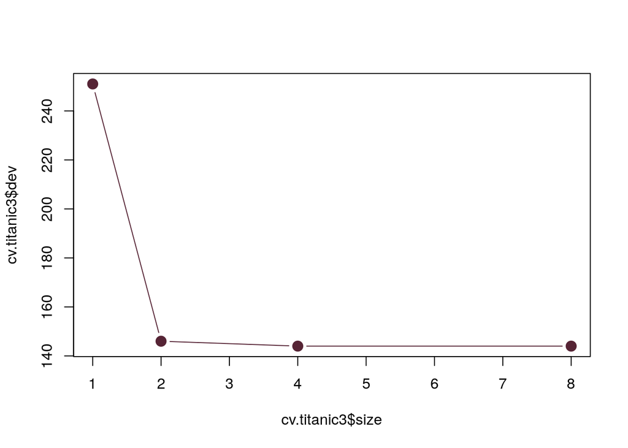

```r
set.seed(3)
cv.titanic3 = cv.tree(tree.titanic3.train, FUN=prune.misclass)
plot(cv.titanic3$size, cv.titanic3$dev, type="b", col="#562435", pch=19, cex=1.5)
```

According to the result, do you think pruning is necessary? Why or why not?

The above chart suggests there is not much difference in `dev` across 2, 4 or 8 so pruning is unlikely to produce a noticeable advantage.

If you think it is necessary, or would like to give it a try, use `prune.misclass()` to prune the tree and evaluate the performance of the pruned tree.

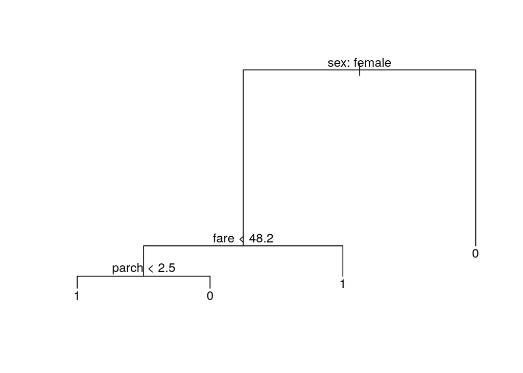

```r
prune.titanic3 = prune.misclass(tree.titanic3.train, best=4)
plot(prune.titanic3)
text(prune.titanic3, pretty=0)
```

```r
prune.yhat = predict(prune.titanic3, test.set, type="class")
mean(prune.yhat != y)
[1] 0.2229008
```